# Actuarial 3 Tarea 3

Actuarial 3

Autor/a

Marcelino Sánchez

Fecha de publicación

7 de noviembre de 2023

# Ejercicio 2: Empalmes

Para un seguro de daños, se conoce que las pérdidas menores a $c$ siguen una distribución $Exp(\frac{1}{\theta})$ con $\theta > 0$, y las pérdidas mayores o iguales a $c$ tienen una distribución $Pareto(\alpha, \beta)$ donde $\alpha > 0$ y $\beta >0$.

1. Se pide demostrar que la función de densidad de la Distribución de Empalme está dada por:

$f_X(x) = p \frac{\theta^{-1}e^{-\frac{x}{\theta}}}{1-e^{-\frac{c}{\theta}}} I(0 < x < c) + (1-p) \frac{\alpha (c+\beta)^{\alpha}}{(x+\beta)^{\alpha + 1}} I(x \geq c)$

Dado:

- $\theta = 100$
- $\alpha = 4$
- $\beta = 200$
- $c = 100$

Se pide:

1. Graficar $f_X(x)$ con $p = 0.6$. Determinar si $f_X(x)$ es continua en $x = 100$.

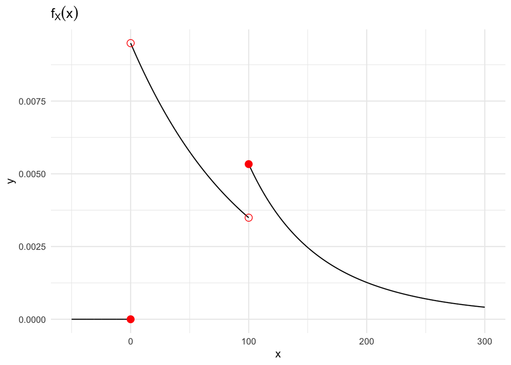

2. Encontrar el valor de $ p $ para que $ f_X(x) $ sea continua en $ x = 100 $ y luego graficar $ f_X(x) $ con este valor.

```r
theta <- 100
alpha <- 4
beta <- 200
c <- 100
aux1 <- ((c+beta)*(theta^(-1))*((exp(-c/theta))/(1-exp(-c/theta)))
 + alpha)
pvalor <- alpha/aux1
```

El valor de p en el cual se satisface la continuidad en c es 0.6961449

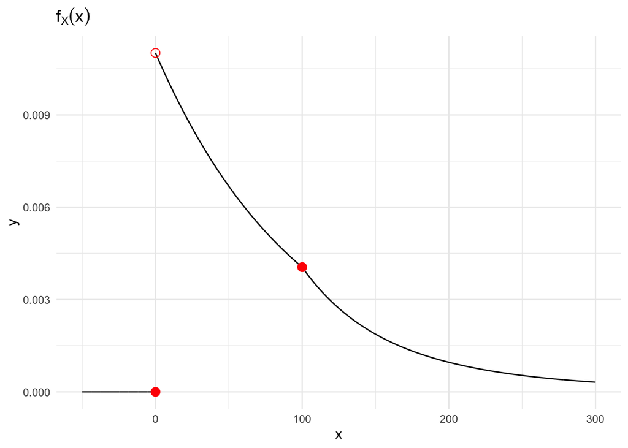

# Ejercicio 4: Colas de las distribuciones

Suponga que $X \sim \text{Pareto}(\alpha, \theta)$ y $Y \sim \text{Gamma}(\tau, \beta)$.

## Comparación de distribuciones

2. Para comparar de manera más justa ambas distribuciones, queremos que ambas tengan media 5 y varianza 75.
3. Encuentre los valores de $\alpha$, $\theta$, $\tau$, y $\beta$.

```r
#Calculamos los parámetros de la pareto
varianza <- 75

esperanza <- 5

aux1 <- varianza/(esperanza^2) +1

aux2 <- varianza/(esperanza^3) -1/esperanza

theta <- aux1/aux2

alpha <- theta/esperanza + 1

#Calculamos los parámetros de la gamma

tau <- (esperanza^2)/varianza

beta <- varianza/esperanza
```

Los valores de los parámetros son:

- $\alpha = 3$
- $\theta = 10$
- $\tau = 0.3333333$
- $\beta = 15$
2. Compare en la misma gráfica ambas funciones de densidad. ¿Qué conclusiones se pueden derivar?

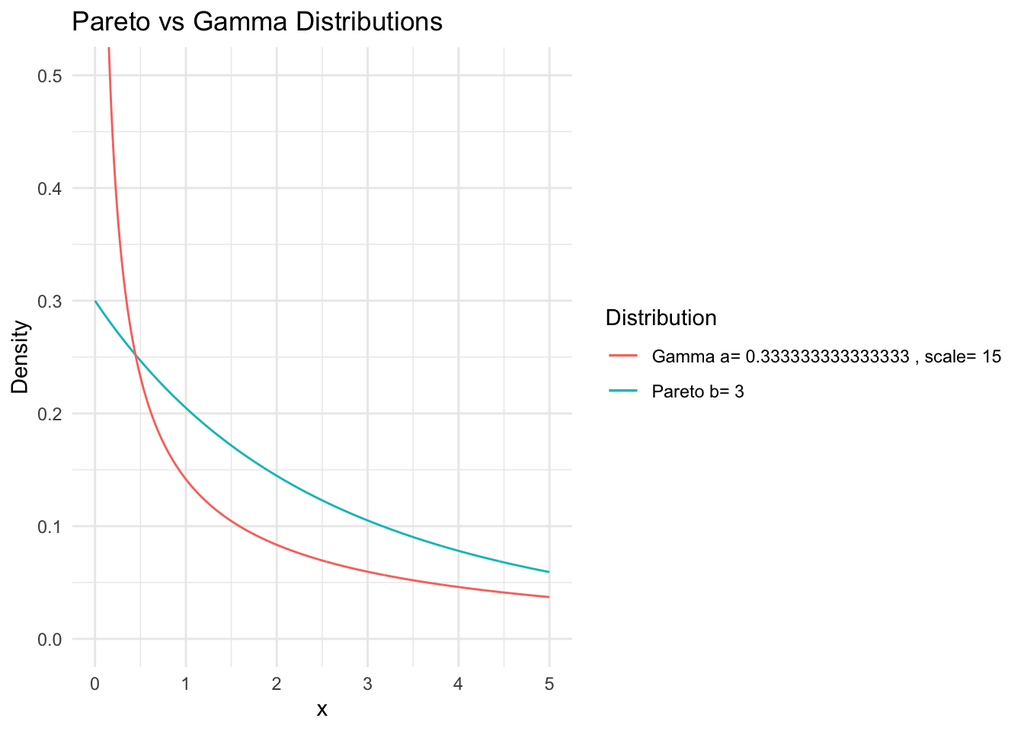

Se puede derivar que la gamma acumula más que la pareto para valores cercanos a cero (aún teniendo la misma varianza y media), por lo que la pareto tiene cola más pesada que la gamma.

# Ejercicio 5

Verosimilitud para datos agrupados. Suponga que las pérdidas de cierto riesgo siguen una distribución con función de distribución acumulada $F(x) = (1 - \frac{\theta}{x})I(\theta, \infty)(x)$, donde $\theta > 0$. Una muestra aleatoria de 20 siniestros contiene 9 pérdidas por debajo de 10 mil dólares, 6 pérdidas entre 10 y 25 mil dólares y 5 pérdidas que exceden los 25 mil dólares. Encuentre el estimador de máxima verosimilitud de $\theta$. [10]

Por principio de máxima verosimilitud tenemos que el logaritmo de la función de verosimilitud para datos agrupados está dada por:

$$\ln(L(\theta)) = 9 \ln\left( F(10000, \theta) - F(0, \theta) \right) + 6 \ln\left( F(25000, \theta) - F(10000, \theta) \right)$$

$$+5\ln\left( 1 - F(25000, \theta)\right)$$

```r
acumulada <- function(x, theta){
  if(x > theta){
    resultado = 1 - (theta/x)
  }else{
    resultado = 0
  }
  return(resultado)
}


verosimilitud <- function(theta){
  resultado <- 9*log(acumulada(10000, theta)-acumulada(0,theta)) +
   6*log(acumulada(25000, theta)-acumulada(10000,theta)) +
   5*log(1-acumulada(25000,theta))
  return(resultado)
}

neg_verosimilitud <- function(theta) {
  return(-verosimilitud(theta))
}

# Usamos la función optimize para encontrar el
#valor de theta que maximiza la verosimilitud
# Establece un rango razonable para
#theta basado en tu conocimiento del problema
resultado <- optimize(neg_verosimilitud, interval=c(0, 9000))
```

El valor de $\theta$ que maximiza la verosimilitud numéricamente es 5499.9999998 .

# Ejercicio 6

Ajuste para datos agrupados. A continuación se presenta la distribución de frecuencias de una muestra de 250 pérdidas de un seguro de hogar.

| Pérdida (miles de pesos) | Frecuencia |
| --- | --- |
| 0 - 50 | 3 |
| 50 - 150 | 54 |
| 150 - 300 | 62 |
| 300 - 500 | 43 |
| 500 - 1,000 | 39 |
| 1,000 - 2,000 | 24 |
| 2,000 - 4,000 | 11 |
| 4,000 - 8,000 | 9 |
| 8,000 - 16,000 | 4 |
| Más de 16,000 | 1 |
| **Total** | **250** |

1. Construya el histograma de frecuencias relativas respectivo. Note que las clases son de distinta longitud. [10]

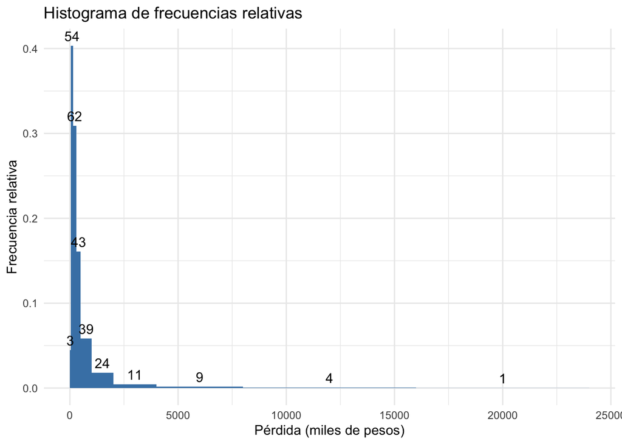

```r
# Crea un vector con los límites de las clases

clases <- c(0, 50, 150, 300, 500, 1000, 2000, 4000, 8000, 16000, 24000)

# Crea un vector con las frecuencias

frecuencias <- c(3, 54, 62, 43, 39, 24, 11, 9, 4, 1)

# Crea un vector con las frecuencias relativas

frecuencias_relativas <- frecuencias/sum(frecuencias)

# Crea un vector con las longitudes de las clases

longitudes_clases <- diff(clases)


# Crea un vector con los factores de ajuste

factores_ajuste <- 1/longitudes_clases

# Crea un vector con las frecuencias relativas ajustadas

frecuencias_relativas_ajustadas <- frecuencias_relativas * factores_ajuste

# Crea un vector con las frecuencias relativas corregidas

frecuencias_relativas_corregidas <- frecuencias_relativas_ajustadas/sum(frecuencias_relativas_ajustadas)

# Crea un vector con los puntos medios de las clases

puntos_medios_clases <- (clases[-1] + clases[-length(clases)])/2

# Crea un data frame con los datos

df <- data.frame( frecuencias, frecuencias_relativas, frecuencias_relativas_ajustadas,
frecuencias_relativas_corregidas, puntos_medios_clases)


# Grafica el histograma
gg1 <-ggplot(df, aes(x = puntos_medios_clases, y = frecuencias_relativas_corregidas)) +
  geom_bar(width = longitudes_clases, stat = "identity", fill = "steelblue") +
  geom_text(aes(label = frecuencias), vjust = -0.5) +
  ggtitle("Histograma de frecuencias relativas") +
  xlab("Pérdida (miles de pesos)") +
  ylab("Frecuencia relativa") +
  theme_minimal()

gg1
```

[figure not shown]

```r
ggplot(df[1:6, ], aes(x = puntos_medios_clases, y = frecuencias_relativas_corregidas)) +
  geom_bar(width = longitudes_clases[1:6], stat = "identity", fill = "steelblue") +
  geom_text(aes(label = round(frecuencias_relativas_corregidas,digits = 5)), vjust = -0.5) +
  ggtitle("Histograma de frecuencias relativas (primeras 8 clases)") +
  xlab("Pérdida (miles de pesos)") +
  ylab("Frecuencia relativa") +
  xlim(c(0, 2000)) +  # Limitar el eje x hasta un poco después de 8,000
  theme_minimal()
```

2. A partir de los datos agrupados, ajuste por máxima verosimilitud la Distribución Exponencial Inversa con función de distribución acumulada $F(x) = e^{-\frac{\theta}{x}} I(0,\infty)(x), \quad \theta > 0$. Especifique $\hat{\theta}$ y grafique la densidad ajustada junto con el histograma del inciso anterior. [10]

Por principio de máxima verosiimilitud tenemos que el logaritmo de la función de verosimilitud para datos agrupados está dada por:

$$\ln(L(\theta)) = \sum_{i=1}^{10} n_i \ln\left( F(b_i, \theta) - F(a_i, \theta) \right)$$

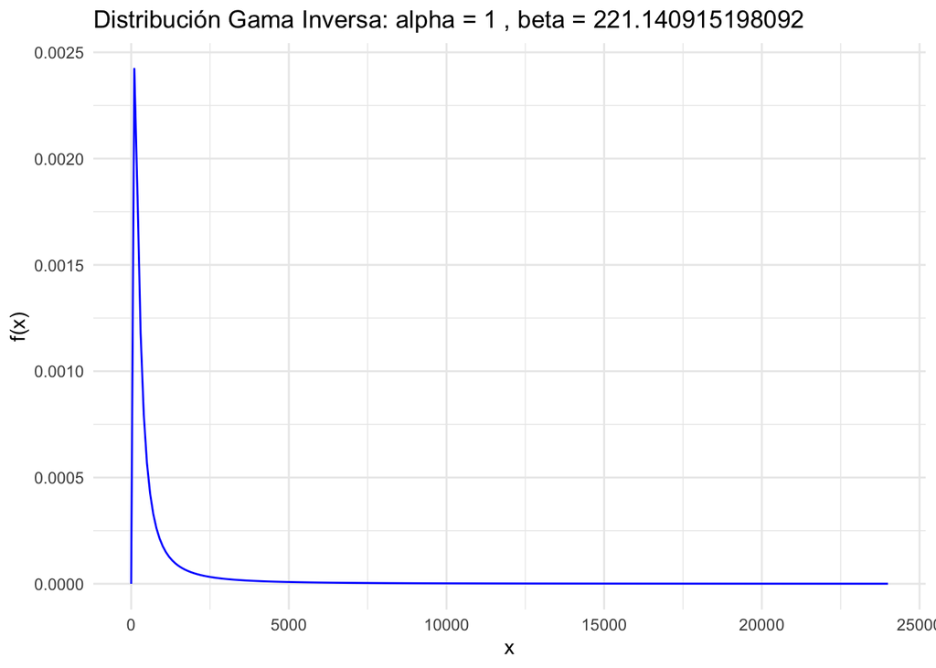

```r
acumulada <- function(x, theta){
  if(x > 0){
    resultado = exp(-theta/x)
  }else{
    resultado = 0
  }
  return(resultado)
}


verosimilitud <- function(theta){
  for(i in 1:10){
    if(i == 1){
      resultado <- frecuencias[i]*log(acumulada(clases[i+1], theta)-acumulada(clases[i],theta))
    }else{
      resultado <- resultado + frecuencias[i]*log(acumulada(clases[i+1], theta)-acumulada(clases[i],theta))
    }
  }
  return(resultado)
}

neg_verosimilitud <- function(theta) {
  return(-verosimilitud(theta))
}

# Usamos la función optimize para encontrar el valor de theta que maximiza la verosimilitud
# Establece un rango razonable para theta basado en tu conocimiento del problema
resultado <- optimize(neg_verosimilitud, interval=c(0, 9000))



# Compute likelihoods

d_gamma_inv <- function(x, theta) {
  ifelse(x > 0, (theta / (x^(2))) * exp(-theta/x),0)
}

# Valores de x
x_vals <- seq(0, 24000, by = 100)

# Calcular la función de densidad para estos valores
y_vals <- sapply(x_vals, d_gamma_inv, theta =resultado$minimum )

# Graficar

data_to_plot2 <- data.frame(x = x_vals, y = y_vals)

ggplot(data_to_plot2, aes(x = x, y = y)) +
  geom_line(color = "blue") +
  ggtitle(paste("Distribución Gama Inversa: alpha =", 1, ", beta =", resultado$minimum)) +
  xlab("x") +
  ylab("f(x)") +
  theme_minimal()
```

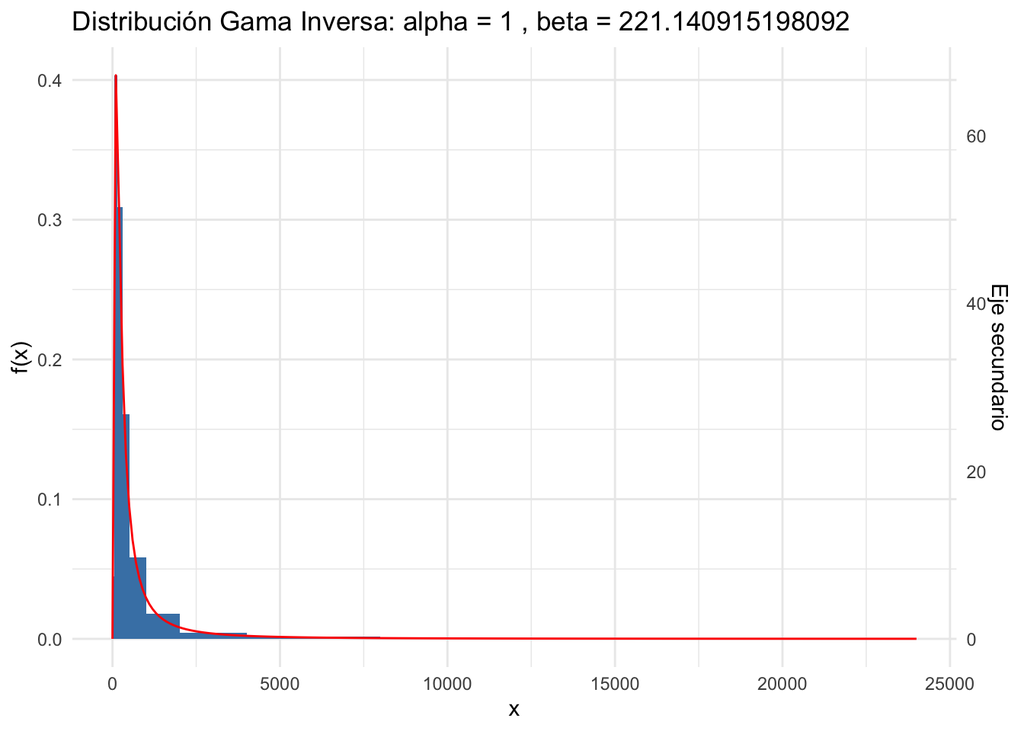

```r
# Primero, configura el ggplot base
plot_base <- ggplot() +
  theme_minimal() +
  xlab("x") + ylab("f(x)")

# Supongo que plot_base y los otros datasets ya están definidos

# Calcula el factor de transformación. Este factor se basará en la
#relación entre los rangos máximos de tus datos.
max_y_data_to_plot2 <- max(data_to_plot2$y)
max_df <- max(df$frecuencias_relativas_corregidas)

# Factor de transformación
trans_factor <- max_y_data_to_plot2 / max_df

final_plot <- plot_base +
  # Primero traza el histograma
  geom_bar(data = df, aes(x = puntos_medios_clases, y = frecuencias_relativas_corregidas,
  width = longitudes_clases), stat = "identity", fill = "steelblue") +
  # Luego traza la línea, pero multiplica los valores por el factor de transformación
  geom_line(data = data_to_plot2, aes(x = x, y = y / trans_factor), color = "red") +
  ggtitle(paste("Distribución Gama Inversa: alpha =", 1, ", beta =", resultado$minimum)) +
  # Añade el eje secundario, dividiendo por el
  #factor de transformación para mostrar los valores reales
  scale_y_continuous(sec.axis = sec_axis(~./trans_factor, name = "Eje secundario"))

# Finalmente, muestra el gráfico
print(final_plot)
```

El valor de $\theta$ que maximiza la verosimilitud numéricamente es 221.1409152 .

# Ejercicio 7

Ajuste de una mezcla. Con base en 180 pérdidas de un seguro de vehículos que cubre automóviles y motocicletas se construyó el siguiente histograma:

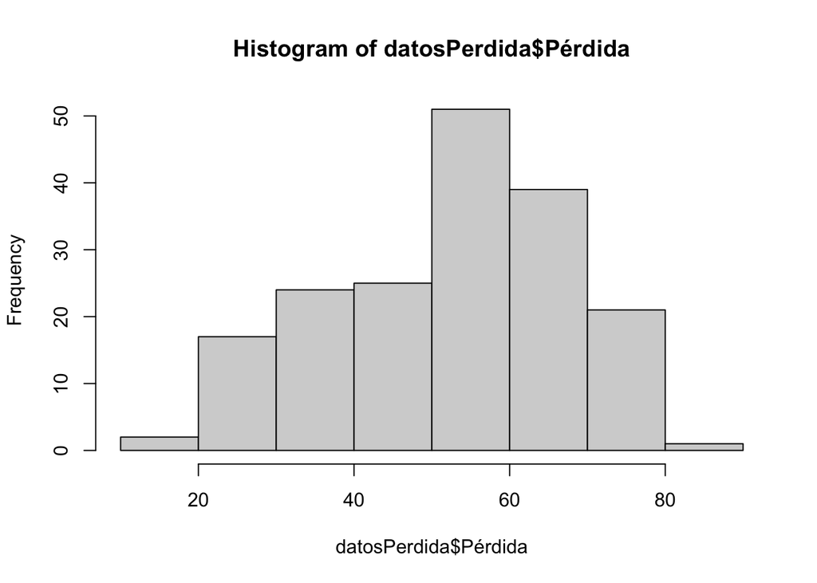

```r
library(readxl)
library(kableExtra)
ruta <- paste0(getwd(), "/bases/Tarea 3.xlsx")
datosPerdida <- read_excel(ruta, sheet = "7", range = "A8:B188")

hist(datosPerdida$Pérdida)
```

Se quiere ajustar una mezcla de distribuciones Ji-Cuadradas con medias $\nu$ y $2\nu$ con ponderadores $\alpha$ y $1-\alpha$, respectivamente, donde $\nu \in \mathbb{Z^+}$ y $0 < \alpha < 1$.

**a)** A partir de los datos individuales, escriba la función de densidad de la mezcla y verifique que los EMV son $\hat{\alpha} = 0.2468$ y $\hat{\nu} = 30$. (Sugerencia: Optimice numéricamente respecto a ambos parámetros, luego fije $\hat{\nu}$ al entero más cercano y maximice nuevamente para obtener $\hat{\alpha}$). [15]

Primero notamos que la función de verosimilitud está dada por:

$$L(\nu, \alpha)= \prod_{i=1}^{180} \left[ \alpha \frac{x^{\frac{\nu}{2}-1} e^{-\frac{x}{2}}}{2^{\frac{\nu}{2}} \Gamma\left(\frac{\nu}{2}\right)} + (1-\alpha)\frac{x^{\nu-1} e^{-\frac{x}{2}}}{2^{\nu} \Gamma(\nu)} \right]$$

Por lo que el logaritmo de la función de verosimilitud está dado por:

$$\ln(L(\nu, \alpha)) = \sum_{i=1}^{180} \left[ \ln\left( \alpha \frac{x^{\frac{\nu}{2}-1} e^{-\frac{x}{2}}}{2^{\frac{\nu}{2}} \Gamma\left(\frac{\nu}{2}\right)} + (1-\alpha)\frac{x^{\nu-1} e^{-\frac{x}{2}}}{2^{\nu} \Gamma(\nu)} \right) \right]$$

```r
# Optimizamos numéricamente respecto a ambos parámetros

mezclaFuncion <- function(x, alpha, nu) {
  alpha * dgamma(x, shape = nu/2, scale = 2) + (1 - alpha) * dgamma(x,
  shape = nu, scale = 2)+.00000001
}

verosimilitud <- function(alpha, nu, datos) {
  log_mezcla <- log(mezclaFuncion(datos, alpha, nu))
  resultado <- sum(log_mezcla)
  return(resultado)
}

neg_verosimilitud <- function(params, datos) {
  alpha <- params[1]
  nu <- params[2]
  -verosimilitud(alpha, nu, datos)
}

# Suponiendo que tienes un dataframe llamado datosPerdida con una columna 'Pérdida'
datos <- datosPerdida$Pérdida

# Valores iniciales para alpha y nu
valores_iniciales <- c(alpha = 0.5, nu = 2)

# Límites para alpha y nu
# alpha está entre 0 y 1, y nu es mayor que 0
limites <- list(c(0.000001, 10), c(1e-6, 50))

# Utilizar optim con el método "L-BFGS-B" para encontrar los parámetros óptimos
resultado_optim <- optim(
  par = valores_iniciales,
  fn = neg_verosimilitud,
  datos = datos,
  method = "L-BFGS-B",
  lower = sapply(limites, `[`, 1), # Límites inferiores
  upper = sapply(limites, `[`, 2)  # Límites superiores
)

# Los parámetros optimizados
(alpha_optim <- resultado_optim$par[1])
```

```
    alpha
0.2428192
```

```r
(nu_optim <- resultado_optim$par[2])
```

```
      nu
29.81585
```

```r
# Optimizamos numéricamente respecto a alpha

# Ahora neg_verosimilitud aceptará solo alpha ya que nu es fijo.
neg_verosimilitud <- function(alpha, datos) {
  nu <- 30  # Fijamos nu a 30
  -verosimilitud(alpha, nu, datos)
}

# Suponiendo que tienes un dataframe llamado datosPerdida con una columna 'Pérdida'
datos <- datosPerdida$Pérdida

# Valor inicial solo para alpha
valor_inicial_alpha <- 0.5

# Límite solo para alpha
limites_alpha <- c(0.000001, 1)

# Utilizar optim con el método "L-BFGS-B" para encontrar el parámetro óptimo de alpha
resultado_optim <- optim(
  par = valor_inicial_alpha,
  fn = neg_verosimilitud,
  datos = datos,
  method = "L-BFGS-B",
  lower = limites_alpha[1], # Límite inferior para alpha
  upper = limites_alpha[2]  # Límite superior para alpha
)

# El parámetro optimizado para alpha
alpha_optim <- resultado_optim$par
```

Con lo cual obtenemos que $\hat{\alpha} = 0.2468169$ y $\hat{\nu} = 30$.

**b)** Grafique la función de densidad ajustada junto con el histograma de frecuencias relativas y obtenga los EMV de las modas. [15]

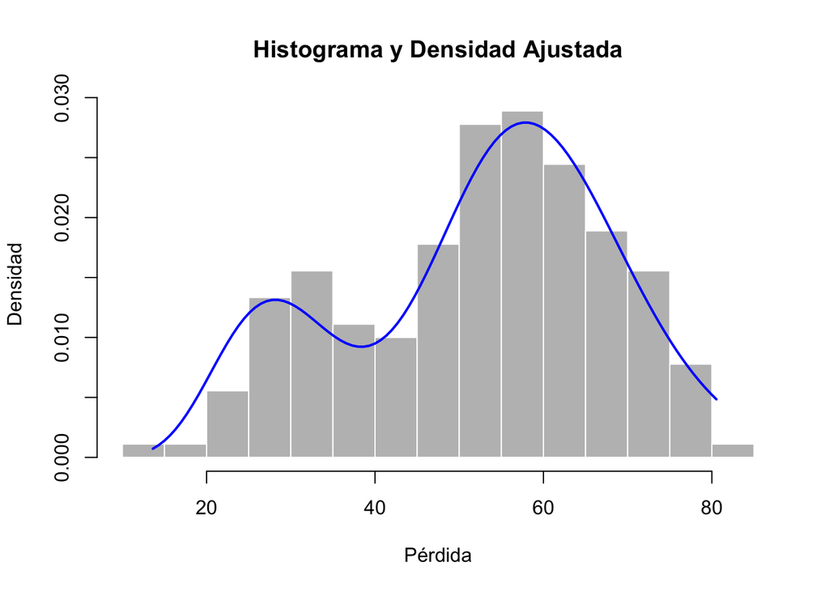

```r
# Asumiendo que alpha_optim contiene el valor de alpha optimizado
alpha_emv <- alpha_optim
nu_emv <- 30  # Valor fijo de nu

# 1. Crear una secuencia de valores sobre los que queremos calcular la densidad ajustada
x_values <- seq(min(datosPerdida$Pérdida), max(datosPerdida$Pérdida), length.out = 100)

# 2. Calcular la función de densidad para cada uno de esos valores
densidad_ajustada <- mezclaFuncion(x_values, alpha_emv, nu_emv)

# 3. Crear el histograma con frecuencias relativas
hist(datosPerdida$Pérdida, breaks = 20, probability = TRUE, col = 'gray', border = 'white',
     main = 'Histograma y Densidad Ajustada',
     xlab = 'Pérdida', ylab = 'Densidad')

# 4. Sobreponer la función de densidad ajustada
lines(x_values, densidad_ajustada, col = 'blue', lwd = 2)
```

```r
# 5. Obtener las modas

# Punto de inicio para la búsqueda de la moda,
#podría ser el valor medio de los datos, por ejemplo
valor_inicial1 <- 60
valor_inicial2 <- 25
# Necesitamos una función que sea negativa para la
#función de densidad para poder minimizarla
neg_densidad_mezcla <- function(x, alpha, nu) {
  -mezclaFuncion(x, alpha, nu)
}
# Usar optim para encontrar la moda de la función de densidad
resultado_moda <- optim(
  par = valor_inicial1,
  fn = neg_densidad_mezcla,
  alpha = alpha_emv,
  nu = nu_emv,
  method = "L-BFGS-B",
  lower = min(datosPerdida$Pérdida), # Límite inferior para la búsqueda
  upper = max(datosPerdida$Pérdida)  # Límite superior para la búsqueda
)

# Usar optim para encontrar la moda de la función de densidad
resultado_moda2 <- optim(
  par = valor_inicial2,
  fn = neg_densidad_mezcla,
  alpha = alpha_emv,
  nu = nu_emv,
  method = "L-BFGS-B",
  lower = min(datosPerdida$Pérdida), # Límite inferior para la búsqueda
  upper = max(datosPerdida$Pérdida)  # Límite superior para la búsqueda
)

# La moda es el punto donde la función de densidad es máxima
moda1 <- resultado_moda$par
moda2 <- resultado_moda2$par
```

Con lo cual los valores de las modas son 57.8813199 y 28.1514919.

# Ejercicio 8

**a)** Construya un histograma de frecuencias relativas con 6 clases de igual longitud entre $30,000$ y $90,000$ dólares. ¿Qué distribuciones paramétricas podrían ajustar a este perfil de siniestros? [10]

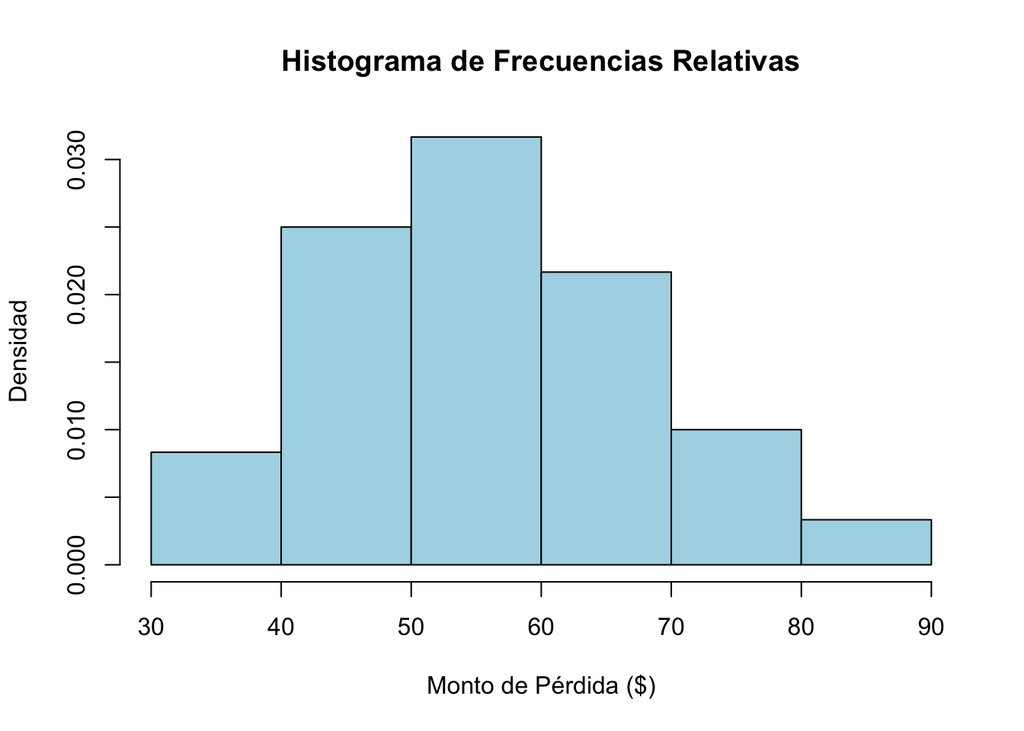

```r
library(readxl)
library(kableExtra)
ruta <- paste0(getwd(), "/bases/Tarea 3.xlsx")
datosPerdida <- read_excel(ruta, sheet = "8", range = "L6:M66")

hist(datosPerdida$Monto,
     breaks = seq(30, 90, length.out = 7), # Define los límites de las clases
     freq = FALSE, # Usa frecuencias relativas en lugar de frecuencias absolutas
     main = "Histograma de Frecuencias Relativas",
     xlab = "Monto de Pérdida ($)",
     ylab = "Densidad",
     col = "lightblue",
     border = "black")
```

**b)** Si se decide ajustar una Distribución Lognormal con parámetros $\mu \in \mathbb{R}$ y $\sigma^2 > 0$, calcule sus respectivos EMV. Grafique la función de distribución acumulada ajustada junto con la Ojiva. ¿Qué puede concluir? (Sugerencia: Recuerde que estos estimadores fueron deducidos en el Ejercicio E19). [10]

Primero notemos que la función de verosimilitud es de la forma:

$$L(\mu, \sigma \mid x_1, \ldots, x_n) = \prod_{i=1}^{n} \frac{1}{x_i \sigma \sqrt{2\pi}} \exp\left(-\frac{(\ln x_i - \mu)^2}{2\sigma^2}\right)$$

y la log-verosimilitud es de la forma:

$$\ln L(\mu, \sigma \mid \underline{X}_{n}) = -n\ln(\sigma) - \frac{n}{2}\ln(2\pi) - \sum_{i=1}^{n}\ln(x_i) - \frac{1}{2\sigma^2}\sum_{i=1}^{n}(\ln x_i - \mu)^2$$

```r
# Optimizamos numéricamente respecto a ambos parámetros

lognormal <- function(x, mu, sigma) {
  dlnorm(x, meanlog = mu, sdlog = sigma)
}

verosimilitud <- function(mu, sigma, datos) {
  log_ver_ind <- log(lognormal(datos, mu, sigma)+.00000001)
  resultado <- sum(log_ver_ind)
  return(resultado)
}

neg_verosimilitud <- function(params, datos) {
  mu <- params[1]
  sigma <- params[2]
  -verosimilitud(mu, sigma, datos)
}

# Suponiendo que tienes un dataframe llamado datosPerdida con una columna 'Pérdida'
datos <- datosPerdida$Monto

# Valores iniciales para alpha y nu
valores_iniciales <- c(mu = log(40), sigma = 10)

# Límites para alpha y nu
# alpha está entre 0 y 1, y nu es mayor que 0
limites <- list(c(.00001, 90), c(.00001, 90))

# Utilizar optim con el método "L-BFGS-B" para encontrar los parámetros óptimos
resultado_optim <- optim(
  par = valores_iniciales,
  fn = neg_verosimilitud,
  datos = datos,
  method = "L-BFGS-B",
  lower = sapply(limites, `[`, 1), # Límites inferiores
  upper = sapply(limites, `[`, 2)  # Límites superiores
)

# Los parámetros optimizados
mu_optim <- resultado_optim$par[1]
sigma_optim <- resultado_optim$par[2]
```

Con lo cual obtenemos que $\hat{\mu} = 4.0013712$ y $\hat{\sigma^{2}} = 0.0381647$.

Ahora procederemos a graficar la función de distribución acumulada ajustada junto con la Ojiva.

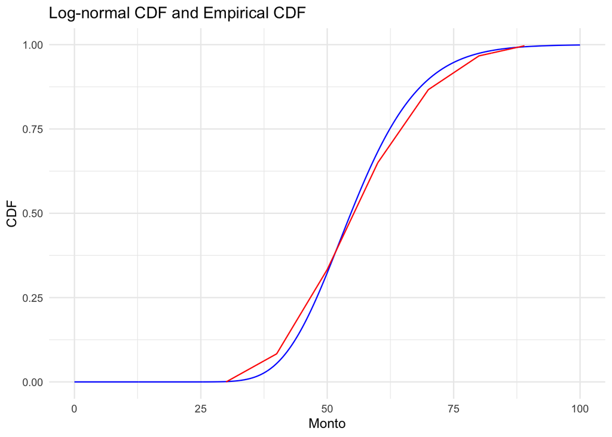

```r
mu_est <- mu_optim
sigma_est <- sigma_optim

# Define una secuencia de valores para los cuales se calculará la ojiva
x_values <- seq(0,100, length.out = 1000)
x_values2 <- seq(30,89, length.out = 1000)
ecdf_datos <- ecdf(datosPerdida$Monto)
# Función de la ojiva

ojiva_lognormal <- function(x){
  particion <- seq(30, 90, length.out = 7)
  for (i in particion){
    if(x <= i & x >= i-10){
      cparticionBefore <- i-10
      cparticionNow <- i
      resultado <-  (cparticionNow -
      x)*ecdf_datos(cparticionBefore)/(cparticionNow-
      cparticionBefore) +
      (x - cparticionBefore)*
      ecdf_datos(cparticionNow)/(cparticionNow- cparticionBefore)
      break
    }
  }
  return(resultado)
}
ojiva_empirica_values <- sapply(x_values2, ojiva_lognormal)

lognormal <- function(x) {
  plnorm(x, meanlog = mu_est, sdlog = sigma_est)
}

library(ggplot2)
# Crear el gráfico con ggplot2
ggplot() +
  geom_line(aes(x= x_values, y = lognormal(x_values)), color = "blue") +
  geom_line(aes(x=x_values2, y = ojiva_empirica_values), color = "red") +
  labs(title = 'Log-normal CDF and Empirical CDF', x = 'Monto', y = 'CDF') +
  theme_minimal() +
  theme(legend.position = "bottomright")
```

Tenemos que tomar en cuenta que la ojiva es un estimador de la función de distribución acumulada similar al histograma. Y al paracer nuestra distribución ajustada sí está pareciéndose a la distribución de los datos. Solo cabe resaltar que subestima abtes de los 50,000 y sobreestima después de los 50,000.

**c)** Construya la Gráfica de Probabilidad para el ajuste del inciso b). ¿Qué puede concluir? [10]

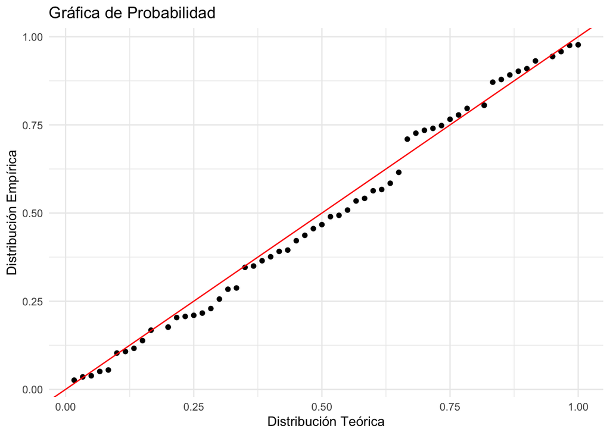

```r
# Carga la librería necesaria para funciones adicionales si es necesario
# Por ejemplo, para la distribución t, necesitas la función qt de la librería stats
library(stats)

# Genera tus datos
datos <- datosPerdida$Monto

# Distribución empírica
dist_empirica <- ecdf(datos)
datos_empirica <- dist_empirica(datos)
# Distribución teórica
datos_teoricos <- lognormal(datos)

data <- data.frame(datos_empirica, datos_teoricos)

# Crea la gráfica de probabilidad
ggplot(data,aes(x=datos_empirica , y= datos_teoricos)) +
  geom_point() +
  geom_abline(slope = 1, intercept = 0, color = "red") +
  labs(title = "Gráfica de Probabilidad", x = "Distribución Teórica",
   y = "Distribución Empírica") +
  theme_minimal()
```

Con esta gráfica es mucho más claro y preciso poder decir que la nuestra distribución ajustada se parece a la de los datos muestreados y por tanto no parecen haber grandes desviaciones. Fue un buen ajuste.

**d)** Aplique la Prueba Kolmogorov-Smirnov para validar el ajuste Lognormal del inciso b). Considere un tamaño de error tipo I del 5%. [10]

```r
# Realizar la prueba de Kolmogorov-Smirnov
ks_result <- ks.test(datosPerdida$Monto, "plnorm", meanlog = mu_est, sdlog = sigma_est)
# Imprimir el resultado
print(ks_result)
```

```
    Asymptotic one-sample Kolmogorov-Smirnov test

data:  datosPerdida$Monto
D = 0.059849, p-value = 0.9826
alternative hypothesis: two-sided
```

Con lo cual no se rechaza la hipótesis nula de que la distribución de los datos es lognormal, es decir, el ajuste fue bueno estadísticamente.

**e)** Aplique la Prueba Ji-Cuadrada para validar el ajuste Lognormal del inciso b). Considere la partición del inciso a) y agregue 2 clases (inicial y final) para abarcar todo el soporte de la Lognormal. Calcule el valor-p para concluir. [10]

```r
mis_datos <- datosPerdida$Monto
# Crear una secuencia de intervalos para la tabla de frecuencia
breaks1 <- seq(30, 90, length.out = 7)  # Ajusta el
#número de intervalos según sea necesario
breaks <- c(-Inf, breaks1, Inf)

# Frecuencias observadas: conteo de datos en cada intervalo
observed <- hist(mis_datos, breaks = breaks, plot = FALSE)$counts

# probabilidades
probabilities <- plnorm(breaks, meanlog = mu_est, sdlog = sigma_est)
diff_prob <- diff(probabilities)

# Realizar la prueba chi-cuadrada
pruebachi <- chisq.test(x = observed, p = diff_prob, rescale.p = TRUE)
kparam <- length(diff_prob) # Número de cajitas
qparam <- 2 # parámetros de la distribución ajustada
df_chi <- kparam - qparam - 1 # Grados de libertad
pvalue <- pchisq(pruebachi$statistic, df = df_chi, lower.tail = FALSE)  # Valor-p
```

Por lo que el estadístico de prueba es 2.6457774 y el valor-p es 0.7543982. Es decir, no hay suficiente evidencia para rechazar la hipótesis nula de que la distribución de los datos es lognormal. Otra vez fue un buen ajuste.

# Ejercicio 9

```r
datos <- read_excel(ruta, sheet = "9", range = "M7:N23")
```

1. Suponga que se quiere ajustar una Distribución Gamma con media $\mu = \alpha\theta$.
2. Calcule los EMV de $\alpha$ y $\theta$. (Sugerencia: Recuerde que en el Ejercicio E14 se obtuvieron estos estimadores o utilice EViews para obtenerlos). [5]

Recordemos que la log de la función de máxima verosimilitud está dada por:

$$\ln L(\alpha, \theta) = (\alpha -1 )*\sum_{i=1}^{n}\ln (x_i)- \sum_{i=1}^{n} \frac{x_{i}}{\theta} -n \ln(\Gamma(\alpha))-n\alpha \ln(\theta)$$

Y derivando parcialmente con respecto a cada parámetro obtenemos las siguientes ecuaciones:

$$\sum_{i=1}^{n}\ln (x_i)-n\frac{\Gamma'(\alpha)}{\Gamma(\alpha)}-n\ln(\theta)=0$$

$$\frac{\sum_{i=1}^{n}x_i}{\theta^{2}}-n\frac{\alpha}{\theta}=0$$

Con lo cual simplificando obtenemos que

$$\theta=\frac{\bar{x}}{\alpha}$$

$$\sum_{i=1}^{n}\ln (x_i)-n\frac{\Gamma'(\alpha)}{\Gamma(\alpha)}-n\ln(\theta)=0$$

Es decir, solo hay que utilizar un método numérico para encontrar el valor de $\alpha$ que cumple la segunda ecuación y con ese valor encontrar el valor de $\theta$.

```r
# Definir la función que representa la segunda ecuación
funcion_objetivo <- function(alpha, x) {
  n <- length(x)
  sum(log(x)) - n * digamma(alpha) - n * log(mean(x) / alpha)
}

# Usar uniroot para encontrar el valor de alpha
# Es importante dar un intervalo donde se espera encontrar la raíz (alpha)
resultado <- uniroot(funcion_objetivo, interval = c(0.001, 100), x = datos$Monto)

# El valor de alpha
alpha_estimado <- resultado$root

# Ahora calcular theta usando la relación dada
theta_estimado <- mean(datos$Monto) / alpha_estimado
```

Con lo cual los valores de $\hat{\alpha}$ y $\hat{\theta}$ son 7.9694794 y 0.2351942 respectivamente.

2. Obtenga el Gráfico Cuantil-Cuantil para el ajuste de la distribución Gamma. ¿Qué puede concluir? (Sugerencia: Utilice EViews). [5]

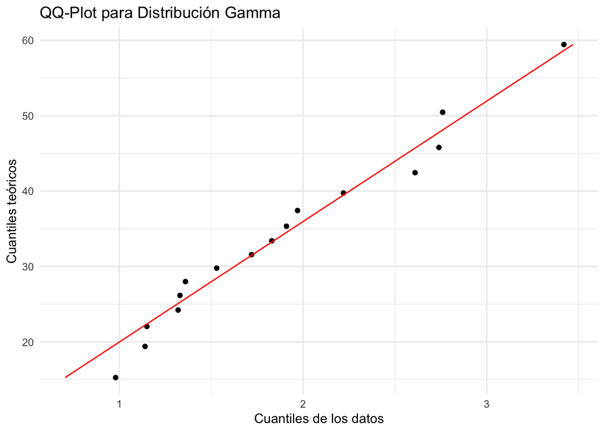

```r
library(ggplot2)

# Ordena tus datos y calcula los cuantiles empíricos
datos$empirical <- datos$Monto
datos$theoretical <- qgamma(ppoints(length(datos$Monto)), shape = alpha_estimado, rate = theta_estimado)

ggplot(data.frame(x = datos$theoretical, y = datos$empirical), aes(sample = y)) +
  stat_qq(distribution = qgamma, dparams = list(shape = alpha_estimado, rate = theta_estimado)) +
  stat_qq_line(distribution = qgamma, dparams = list(shape = alpha_estimado,
  rate = theta_estimado), color = "red") +
  labs(title = "QQ-Plot para Distribución Gamma",
  x = "Cuantiles teóricos", y = "Cuantiles de los datos") +
  coord_flip()+
  theme_minimal()
```

Con lo cual podemos ver que la distribución Gamma es un buen ajuste para los datos.

3. Aplique la Prueba de Razón de Verosimilitudes con un nivel de significancia del 5% para determinar si el monto de las reclamaciones corresponde a una Gamma con media $\mu_0 = 2$. (Sugerencia: Note que a pesar de que la distribución Gamma tiene 2 parámetros, la prueba se debe hacer sólo con un parámetro pues $T(\mu) = (\alpha, \theta) = \alpha\theta$, con $T: \mathbb{R}^2 \rightarrow \mathbb{R}$. No olvide obtener el EMV restringido considerando el valor de $H_0$). [15]

```r
logverosimilitud <- function(alpha, theta, x) {
  n <- length(x)
  resultado <- (alpha - 1) * sum(log(x)) - sum(x / theta) -
  n * log(gamma(alpha)) - n * alpha * log(theta)
  return(resultado)
}

logverosimilitud_restringida <- function(alpha, x) {
  n <- length(x)
  theta <- 2 / alpha
  resultado <- (alpha - 1) * sum(log(x)) - sum(x / theta) -
  n * log(gamma(alpha)) - n * alpha * log(theta)
  return(resultado)
}

# Obtener el EMV restringido

neg_logverosimilitud_restringida <- function(alpha, x) {
  -logverosimilitud_restringida(alpha, x)
}

resultado_optim <- optim(
  par = 1,
  fn = neg_logverosimilitud_restringida,
  x = datos$Monto,
  method = "L-BFGS-B",
  lower = 0.00001, # Límite inferior para alpha
  upper = 100  # Límite superior para alpha
)

alpha_restringido <- resultado_optim$par
theta_restringido <- 2 / alpha_restringido

logverosimilitud_restringida <- logverosimilitud(alpha_restringido,
 theta_restringido, datos$Monto)

logverosimilitud_original <- logverosimilitud(alpha_estimado,
theta_estimado, datos$Monto)

LR_test <- 2 * (logverosimilitud_original -  logverosimilitud_restringida)

valorptest <- 1 - pchisq(LR_test, df = 1)
```

Con lo cual obtuvimos que el valor de la razón de verosimilitudes es 0.517096 y el valor-p es 0.4720831. Por lo que no se rechaza la hipótesis nula de que el monto de las reclamaciones corresponde a una Gamma con media $\mu_0 = 2$.

2. Suponga que se quiere ajustar una distribución Weibull $(\gamma, \theta)$, $\gamma > 0$ y $\theta > 0$.

Primero notemos que la función de verosimilitud está dada por:

$$L(\theta, \gamma)= \frac{\gamma^{n}}{\theta^{\gamma n}}\left(\Pi_{i=1}^{n}x_{i}\right)^{\gamma-1}e^{-\sum_{i=1}^{n}(\frac{x_{i}}{\theta})^{\gamma}}$$

Con lo cual la log-verosimilitud está dada por:

$$\ln L(\theta, \gamma)= n\ln(\gamma)-\gamma n\ln(\theta)+(\gamma-1)\sum_{i=1}^{n}\ln(x_{i})-\sum_{i=1}^{n}\left(\frac{x_{i}}{\theta}\right)^{\gamma}$$

1. Obtenga los EMV de $\gamma$ y $\theta$. Calcule su log-verosimilitud y grafique la f.d.a. empírica y la f.d.a. ajustada. ¿Qué puede concluir? [10]

```r
#Tambien se pudo usar de MASS  fitdistr(x, densfun, start, ...)
logveromisimilitud <- function(x, theta, gamma) {
  n <- length(x)
  resultado <- n * log(gamma) - gamma * n * log(theta) +
  (gamma - 1) * sum(log(x)) - sum((x / theta)^gamma)
  return(resultado)
}

neg_logverosimilitud <- function(params, x) {
  theta <- params[1]
  gamma <- params[2]
  -logveromisimilitud(x, theta, gamma)
}

# Valores iniciales para theta y gamma
valores_iniciales <- c(theta = 1, gamma = 1)

# Límites para theta y gamma
limites <- list(c(0.00001, 100), c(0.00001, 100))

# Utilizar optim con el método "L-BFGS-B" para encontrar los parámetros óptimos

resultado_optim <- optim(
  par = valores_iniciales,
  fn = neg_logverosimilitud,
  x = datos$Monto,
  method = "L-BFGS-B",
  lower = sapply(limites, `[`, 1), # Límites inferiores
  upper = sapply(limites, `[`, 2)  # Límites superiores
)

# Los parámetros optimizados

theta_estimado <- resultado_optim$par[1]
gamma_estimado <- resultado_optim$par[2]

logver1 <- logveromisimilitud(datos$Monto, theta_estimado, gamma_estimado)
```

Con lo cual los valores de $\hat{\theta}$ y $\hat{\gamma}$ son 2.105692 y 2.940197 respectivamente. Además, el valor de la log-verosimilitud es -16.2594217.

Ahora graficaremos la f.d.a. empírica y la f.d.a. ajustada.

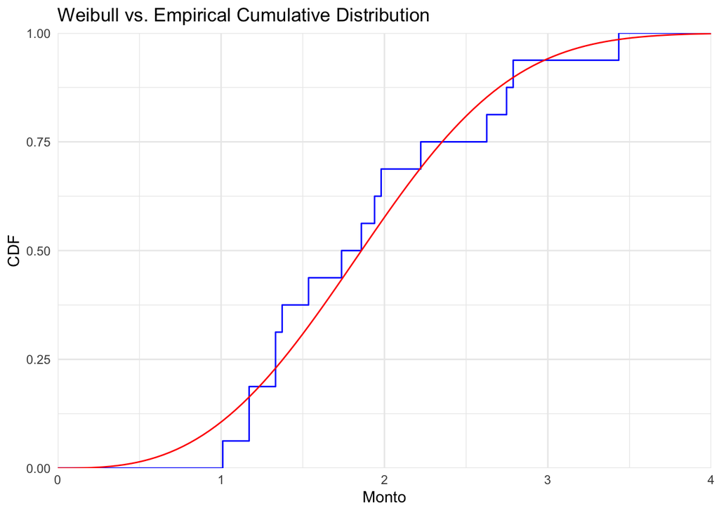

```r
# Crear un nuevo dataframe con valores para las funciones de distribución acumulativa
n <- 100
valores <- seq(0, 4, length.out = n)
df_weibull <- data.frame(
  Monto = valores,
  FittedWeibull = pweibull(valores, shape = gamma_estimado, scale = theta_estimado)
)

# Crear la distribución empírica acumulada (ECDF)
df_empirica <- data.frame(
  Monto = valores,
  Empirical = ecdf(datos$Monto)(valores)
)

# Combinar ambos dataframes
df_combined <- merge(df_weibull, df_empirica, by = "Monto")

# Gráfico con ggplot2
ggplot() +
  geom_step(aes(x = Monto, y = Empirical), data = df_empirica, color = "blue") +
  geom_line(aes(x = Monto, y = FittedWeibull), data = df_weibull, color = "red") +
  labs(title = "Weibull vs. Empirical Cumulative Distribution",
       x = "Monto",
       y = "CDF") +
  theme_minimal() +
  scale_x_continuous(expand = c(0, 0)) +
  scale_y_continuous(expand = c(0, 0))
```

Al parecer fue un buen ajuste pues la f.d.a. ajustada se parece mucho a la f.d.a. empírica. Pero cabe señalar que la f.d.a. ajustada sobreestima poco antes de 1.5 y mayor a 2.3 aproximadamente, y subestima en los otros casos.

2. Para el ajuste del inciso anterior aplique las pruebas Kolmogorov-Smirnov y Anderson-Darling considerando un nivel de significancia del 5%. (Sugerencia: Utilice EViews). [5]

```r
# Realizar la prueba de Kolmogorov-Smirnov
ks_result <- ks.test(datos$Monto, "pweibull",
shape = gamma_estimado, scale = theta_estimado)

print(ks_result)
```

```
    Exact one-sample Kolmogorov-Smirnov test

data:  datos$Monto
D = 0.13339, p-value = 0.9031
alternative hypothesis: two-sided
```

```r
# Realizar la prueba de Anderson-Darling
library(ADGofTest)
# Define una función de distribución acumulada para la Weibull con tus parámetros estimados
pweibull_with_params <- function(q) {
  pweibull(q, shape = gamma_estimado, scale = theta_estimado)
}

# Realiza la prueba de Anderson-Darling usando tu
#vector de datos y la función de distribución definida
ad_result <- ADGofTest::ad.test(datos$Monto, pweibull_with_params)

# Ver los resultados de la prueba
print(ad_result)
```

```
    Anderson-Darling GoF Test

data:  datos$Monto  and  pweibull_with_params
AD = 0.38855, p-value = 0.8582
alternative hypothesis: NA
```

En las dos pruebas no se rechaza la hipótesis nula de que la distribución de los datos es Weibull. Por lo que fue un buen ajuste.

3. Suponga que $\gamma = 3$ y que se aplica un deducible de 1.5 millones de dólares. Obtenga en este caso el EMV de $\theta$ y calcule su log-verosimilitud. [10]

En este caso solo notemos que ahora la función de verosimilitud está dada por:

$$L(\theta)=\frac{ \frac{3^{n}}{\theta^{3 n}}\left(\Pi_{i=1}^{n}x_{i}\right)^{2}e^{-\sum_{i=1}^{n}(\frac{x_{i}}{\theta})^{3}}}{ e^{(\frac{1.5}{\theta})^{3n}}}$$

Con lo cual la log-verosimilitud está dada por:

$$\ln L(\theta)= n\ln(3)-3 n\ln(\theta)+2\sum_{i=1}^{n}\ln(x_{i})-\sum_{i=1}^{n}\left(\frac{x_{i}}{\theta}\right)^{3}+n\left(\frac{1.5}{\theta}\right)^{3}$$

Considerando que ahora $n$ es el número de datos mayores al deducible, los demás los ignoramos.

```r
datosDeducible <- datos[datos$Monto >= 1.5,]

# logVerosimilitud

logveromisimilitud <- function(x, theta) {
  n <- length(x)
  resultado <- n * log(3) - 3 * n * log(theta) +
  (3 - 1) * sum(log(x)) - sum((x / theta)^3)+n*(1.5/theta)^3
  return(resultado)
}

neglogverosimilitud <- function(params, x) {
  theta <- params[1]
  -logveromisimilitud(x, theta)
}

# Valores iniciales para theta
valores_iniciales <- 1

# Límites para theta
limites <- list(c(0.00001, 100))

# Utilizar optim con el método "L-BFGS-B" para encontrar los parámetros óptimos

resultado_optim <- optim(
  par = valores_iniciales,
  fn = neglogverosimilitud,
  x = datosDeducible$Monto,
  method = "L-BFGS-B",
  lower = sapply(limites, `[`, 1), # Límites inferiores
  upper = sapply(limites, `[`, 2)  # Límites superiores
)

# Los parámetros optimizados

theta_estimado <- resultado_optim$par[1]
logver2 <- logveromisimilitud(datosDeducible$Monto, theta_estimado)
```

Por lo tanto, el valor de $\hat{\theta}$ es 2.1965479 y el valor de la log-verosimilitud es -6.8070177.

4. Suponga que $\gamma = 3$ y que no se aplica deducible pero se establece un límite de aseguramiento de 2.5 millones de pesos. Obtenga en este caso el EMV de $\theta$ y calcule su log-verosimilitud. [10]

En este caso la función de verosimilitud está dada por:

$$L(\theta)=\frac{3^{m_1}}{\theta^{3 m_1}}\left(\Pi_{i=1}^{m_1}x_{i}\right)^{2}e^{-\sum_{i=1}^{m_1}(\frac{x_{i}}{\theta})^{3}}(e^{-\sum_{i=1}^{m_2}(\frac{2.5}{\theta})^{3}})$$

donde $m_1$ es el número de datos menores al límite de aseguramiento y $m_2$ es el número de datos mayores al límite de aseguramiento.

Y por lo tanto la log-verosimilitud está dada por:

$$\ln L(\theta)= m_1\ln(3)-3 m_1\ln(\theta)+2\sum_{i=1}^{m_1}\ln(x_{i})-\sum_{i=1}^{m_1}\left(\frac{x_{i}}{\theta}\right)^{3}-\sum_{i=1}^{m_2}\left(\frac{2.5}{\theta}\right)^{3}$$

```r
logveromisimilitud <- function(x, theta) {
  n <- length(x)
  xind <- x[x < 2.5]
  xout <- x[x >= 2.5]
  m1 <- length(xind)
  m2 <- length(xout)
  resultado <- m1 * log(3) - 3 * m1 * log(theta) +
  (3 - 1) * sum(log(xind)) - sum((xind / theta)^3)-m2*(2.5 / theta)^3
  return(resultado)
}

neglogverosimilitud <- function(params, x) {
  theta <- params[1]
  -logveromisimilitud(x, theta)
}

# Valores iniciales para theta
valores_iniciales <- 1

# Límites para theta
limites <- list(c(0.00001, 100))

# Utilizar optim con el método "L-BFGS-B" para encontrar los parámetros óptimos

resultado_optim <- optim(
  par = valores_iniciales,
  fn = neglogverosimilitud,
  x = datos$Monto,
  method = "L-BFGS-B",
  lower = sapply(limites, `[`, 1), # Límites inferiores
  upper = sapply(limites, `[`, 2)  # Límites superiores
)

# Los parámetros optimizados

theta_estimado <- resultado_optim$par[1]
logver3 <- logveromisimilitud(datos$Monto, theta_estimado)
```

Con lo cual el valor de $\hat{\theta}$ es 2.1176923 y el valor de la log-verosimilitud es -16.1975445.

22. Calcule los Criterios de Información de Akaike, Schwartz y Hannan-Quinn para los modelos ajustados en los subincisos i), iii) y iv). ¿Cuál modelo se prefiere? Justifique brevemente su respuesta. [5]

```r
# Criterios
akaike_criterio <- function(logverosimilitud, k, n) {
  resultado <- (-2 * logverosimilitud + 2 * k)/n
  return(resultado)
}

schwartz_criterio <- function(logverosimilitud, k, n) {
  resultado <- (-2 * logverosimilitud + 2 * log(n))/n
  return(resultado)
}

hannan_quinn_criterio <- function(logverosimilitud, k, n) {
  resultado <- (-2 * logverosimilitud + 2 * k * log(log(n)))/n
  return(resultado)
}
```

|  | (i) | (ii) | (iii) |
| --- | --- | --- | --- |
| n | 16 | 10 | 16 |
| Log-verosimilitud | -16.2594217 | -6.8070177 | -16.1975445 |
| q | 2 | 1 | 1 |
| **Criterios de información** |  |  |  |
| Akaike | 2.2824277 | 1.5614035 | 2.1496931 |
| Schwartz | 2.3790013 | 1.8219206 | 2.3712666 |
| Hannan-Quinn | 2.2873731 | 1.52821 | 2.1521657 |

# Ejercicio 11: Aproximación Binomial Negativa por Poisson

Suponga que
$$Y \sim \text{Po}(\lambda), \quad \lambda > 0;$$

$$N_i \sim \text{iid Geo}(p), \quad 0 < p < 1;$$

y que

$$N = N_1 + N_2 + \ldots + N_r, \quad r \in \mathbb{Z}^+.$$

4. Para $N \sim \text{BN}(50, 0.2)$ se quieren obtener $P(N = 0)$ y $P(N - E[N] \leq \sigma)$.

   i) Calcule exactamente ambas probabilidades. [5]

   $$P(N = 0)$$

   $$P(N - E[N] \leq \sigma)$$

```r
# Establecer los parámetros para la primera
size <- 50    # Número deseado de éxitos
prob <- .2    # Probabilidad de éxito en cada ensayo
x <- 0

# Calcular la probabilidad
probabilidad1 <- dnbinom(x, size, prob)

#-----------------------------
# Parámetros de la distribución binomial negativa
size <- 50  # número de éxitos deseado
prob <- 0.2 # probabilidad de éxito en cada ensayo

# Calcular la media y la desviación estándar
media <- size* (1 - prob) / prob
varianza <- size * (1 - prob) / (prob^2)
desviacion_std <- sqrt(varianza)

# Calcular la probabilidad de que N esté dentro de una desviación estándar de la media
limite_superior <- pnbinom((desviacion_std+media), size = size, prob = prob)

probabilidad2 <- limite_superior
```

```
Notemos que las probabilidades son:
```

$$P(N = 0) = 1.1258999\times 10^{-35}$$

$$P(N - E[N] \leq \sigma)= 0.8412284$$

ii) Aproxime ambas probabilidades mediante la distribución Poisson. ¿Cuál es el error de la aproximación? [5]

```r
  # Calcular la probabilidad de que N esté dentro de una desviación estándar de la media
lambda <-  size* (1 - prob) / prob
media <-  lambda
varianza <- lambda
desviacion_std <- sqrt(varianza)

limite_superior <- ppois((desviacion_std+media), lambda= lambda)

probabilidad3 <- limite_superior

# calculamos proba de n=0

probabilidad4 <- dpois(0, lambda)

error1 <- abs(probabilidad4-probabilidad1)
error2 <- abs(probabilidad3-probabilidad2)
```

Con lo cual obtenemos lo siguiente

$$P(N = 0) = 1.3838965\times 10^{-87}$$

$$P(N - E[N] \leq \sigma)= 0.8473017$$

Y el error de aproximación a cada son los siguientes:

$$\text{error} (P(N = 0))=1.1258999\times 10^{-35}$$

$$\text{error}(P(N - E[N] \leq \sigma))=0.0060733$$

iii) Aproxime ambas probabilidades mediante el Teorema Central del Límite aplicando el Ajuste de Yate. ¿Cuál es el error de aproximación? ¿Qué puede concluir? [10]

En este caso contruimos $N=\sum_{i=1}^{m} N_{i}$ donde $N_{i}\sim \textbf{Geo}(p)$ con lo cual por el TCL tenemos:

$$\frac{\sum_{i=1}^{m}N_{i}-m\frac{1-p}{p}}{\sqrt{m\frac{1-p}{p^{2}}}}\dot{\sim} N(0,1)$$

y ahora sí podemos aproximar con Normal y con el ajuste de Yate.

```r
media <- size* (1 - prob) / prob

varianza <- size * (1 - prob) / (prob^2)

desviacion_std <- sqrt(varianza)

# Calcular la probabilidad de que N esté dentro de una desviación estándar de la media

limite_superior <- pnorm((desviacion_std+media+.5), mean = media, sd = desviacion_std)

probabilidad5 <- limite_superior

# calculamos proba de n=0

probabilidad6 <- pnorm(0+.5, mean = media, sd = desviacion_std)-
pnorm(0-.5, mean = media, sd = desviacion_std)
```

Con lo cual obtenemos lo siguiente

$$P(N = 0)\approx P(N \leq 0 + .5) - P(N \leq 0 - .5)= 2.6045092\times 10^{-11}$$

$$P(N - E[N] \leq \sigma) \approx P(N \leq \sigma + E[N]+.5)$$

$$=0.8451404$$

donde $N\dot{\sim} N(E[N],Var(N))$

Y los errores de aproximación fueron los siguientes:

$$\text{error} (P(N = 0))=2.6045092\times 10^{-11}$$

$$\text{error}(P(N - E[N] \leq \sigma))=0.003912$$

# Ejercicio 12 **Clase (a, b, 0) vs. Clase (a, b, 1).**

Suponga que $N \sim \text{Bin}(m, q)$, con $m \in \mathbb{Z}^+$ y $0 < q < 1$.

1. Demuestre que $N$ pertenece a la Clase $(a, b, 0)$ y especifique los valores de los parámetros $a$ y $b$, así como de $P(N = 0)$. [10]
2. Obtenga la función de masa de probabilidad de la distribución Binomial truncada en cero y verifique analíticamente que pertenece a la Clase $(a, b, 1)$. [10]
3. Si $m = 20$ y $q = 0.3$, grafique la función de masa de probabilidad de $N$ junto con la función de masa de probabilidad de su respectiva distribución Binomial modificada en cero considerando $P(N = 0) = 0.2$. Verifique numéricamente que la Binomial modificada en cero pertenece a la Clase $(a, b, 1)$. [10]

Primero notemos que estas son las gráficas de las distribuciones binomiales originales y modificadas en cero.

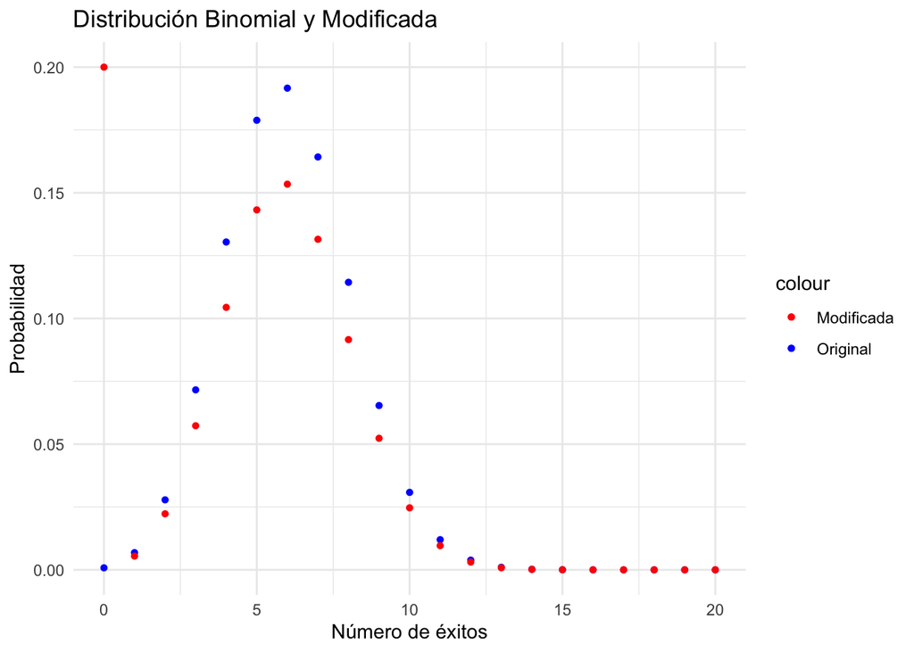

```r
library(ggplot2)

# Parámetros de la distribución binomial
n <- 20
p <- 0.3

# Probabilidad modificada en cero
p0_mod <- 0.2

# Vector de éxitos
x <- 0:n

# Función de probabilidad de masa de la distribución binomial original
dbinom_original <- dbinom(x, size = n, prob = p)

# Ajustar la distribución binomial modificada
# Primero, calcula la probabilidad de 0 éxitos de la distribución binomial original
p0_original <- dbinom_original[1]

# Calcula el factor de ajuste
adjust_factor <- (1-p0_mod) / (1 - p0_original)

# Aplica el factor de ajuste a las probabilidades de 1 a n éxitos
dbinom_modified <- dbinom_original
dbinom_modified[-1] <- dbinom_original[-1] * (adjust_factor)

# Asegúrate de que la suma de las probabilidades sea 1
dbinom_modified[1] <- p0_mod

# Crea un dataframe para graficar
df <- data.frame(x, dbinom_original, dbinom_modified)

# Graficar usando ggplot2
ggplot(df, aes(x = x)) +
  geom_point(aes(y = dbinom_original, colour = "Original"), size = 1.2) +
  geom_point(aes(y = dbinom_modified, colour = "Modificada"), size = 1.2) +
  labs(x = "Número de éxitos", y = "Probabilidad") +
  scale_colour_manual(values = c("Original" = "blue", "Modificada" = "red")) +
  ggtitle("Distribución Binomial y Modificada") +
  theme_minimal()
```

Ahora notemos que la binomial modificada pertenece a la clase $(a,b,1)$ pues si resolvemos el sistema de ecuaciones formado por la relación de recurrencia de las primeras probas tenemos:

$$\frac{p_{2}}{p_{1}}=a+\frac{b}{2}$$

$$\frac{p_{3}}{p_{2}}=a+\frac{b}{3}$$

```r
# Resolvemos el sistema de ecuaciones
# Definir la matriz de coeficientes
A <- matrix(c(1, .5, 1, 1/3), nrow = 2, byrow = TRUE)

# Definir el vector de constantes
B <- c(dbinom_modified[3]/dbinom_modified[2], dbinom_modified[4]/dbinom_modified[3])

# Resolver para X
X <- solve(A, B)
a=X[1]
b=X[2]
```

Con lo cual tenemos que $a=-0.4285714$ y $b=9$. y

Y solo verificamos que a partir de la relación de recurrencia obtengamos las probabilidades exactas de la distribución binomial modificada.

```r
# Definir la función de probabilidad de masa de la distribución binomial modificada

binom_modified_num <- c(dbinom_modified[1], dbinom_modified[2],1:19)

for (i in 1:19){
  binom_modified_num[i+2] <- binom_modified_num[i+1]*(a+b/(i+1))
}

binom_modified_num-dbinom_modified
```

```
 [1] 0.000000e+00 0.000000e+00 0.000000e+00 6.938894e-18 2.498002e-16
 [6] 8.881784e-16 1.804112e-15 2.442491e-15 2.470246e-15 2.060851e-15
[11] 1.332268e-15 6.904199e-16 2.896988e-16 9.963818e-17 2.718637e-17
[16] 5.963112e-18 1.024910e-18 1.344665e-19 1.269557e-20 7.868556e-22
[21] 2.716125e-23
```

Y como podemos ver la diferencia entre la lista obtenida y la lista de las probabilidades de la binomial modificada es cero o muy cercana a cero numéricamente, por lo que la binomial modificada pertenece a la clase $(a,b,1)$.